# AEEM 3062

# HOMEWORK # 5

# 2022-2023 SPRING

### Name: Slade Brooks

### M#: 13801712

### DUE: 11.59 PM on 2/16/2023

## Problem 1

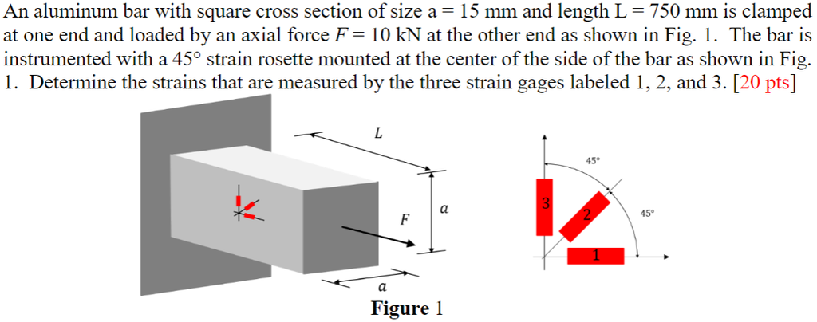

First we will find the poisson's ratio and young's modulus of aluminum from slides: $$ E = 6.89E10 Pa \quad v = 0.34 $$

Then we will find $\epsilon_{xx}$, $\epsilon_{yy}$, and $\epsilon_{zz}$ given by:

$$ \epsilon_{xx}=\frac{F}{EA} \quad \epsilon_{yy}=-v\frac{F}{EA} $$

$\epsilon_{zz}$ is 0 since the rosette is mounted on the XY plane.

$$ \epsilon_{xx} = \frac{10000 N}{6.89E10 Pa * 0.015^{2}m^{2}} = 6.45E-4 $$

$$ \epsilon_{yy} = -(0.34)\frac{10000 N}{6.89E10Pa*0.015^{2}m^{2}} = -2.193E-4 $$

Then we can determine the strain in each direction by using the equations for a $45^{\circ}$ strain rosette:

$$ \epsilon_{1}=\epsilon_{xx}=\fbox{$6.45E-4 = \epsilon_{1}$} $$

$$ \epsilon_{2}=\frac{\epsilon_{xx}+\epsilon_{yy}}{2}+\frac{\gamma_{xy}}{2} = \frac{6.45E-4 -2.193E-4}{2} + \frac{0}{2} = \fbox{$2.1287E-4 = \epsilon_{2}$} $$

$$ \epsilon_{3} = \epsilon_{zz} = \fbox{$0 = \epsilon_{3}$} $$

## Problem 2

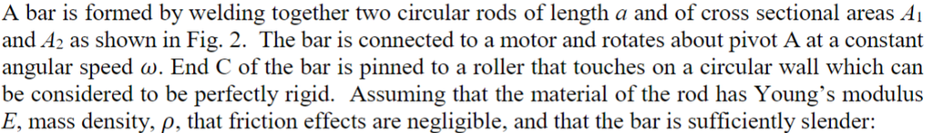

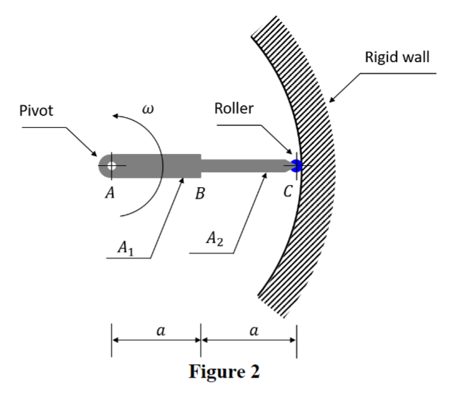

### Part A

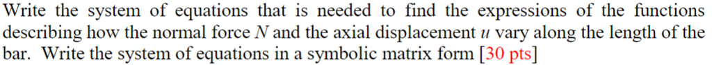

For section A-B, the body force is: $$ n(x) = A_{1} \rho \omega^{2} x $$

Then the normal force is described by:

$$ \frac{\partial N}{\partial x} + n(x) = 0 $$

$$ \frac{\partial N}{\partial x} = -A_{1}\rho\omega^{2}x $$

Then the integral is taken:

$$ N(x) = -A_{1}\rho\omega^{2}\frac{x^{2}}{2} + c_{1} $$

For section B-C, the normal force is the same but with a different area and coefficient:

$$ N(x) = -A_{2}\rho\omega^{2}\frac{x^{2}}{2} + c_{2} $$

Then we find u(x) by:

$$ \frac{du}{dx} = \frac{N}{EA} $$

For section A-B:

$$ \frac{du}{dx} = \frac{N}{EA} = \frac{-A_{1}\rho\omega^{2}x^{2}}{2EA} + \frac{c_{1}}{EA} $$

And then taking the integral gives:

$$ u(x) = \frac{-\rho\omega^{2}x^{3}}{6E} + \frac{c_{1}x}{EA_{1}} + c_{3} $$

And for section B-C:

$$ u(x) = \frac{-\rho\omega^{2}x^{3}}{6E} + \frac{c_{2}x}{EA_{2}} + c_{4} $$

Then we will define the boundary conditions at locations A and C:

$$ u(A) = u(0) = 0 \\ u(C) = u(2a) = 0 $$

Then at point B, we know that N(x) A-B and N(x) B-C must be equal so that the forces are balanced. Also, u(x) for both must equal each other so that the beam is not merging into itself or ripping apart.

This allows us to substitute to get 2 new equations:

$$ -A_{1}\rho\omega^{2}\frac{x^{2}}{2} + c_{1} = -A_{2}\rho\omega^{2}\frac{x^{2}}{2} + c_{2} $$

$$ \frac{-\rho\omega^{2}x^{3}}{6E} + \frac{c_{1}x}{EA_{1}} + c_{3} = \frac{-\rho\omega^{2}x^{3}}{6E} + \frac{c_{2}x}{EA_{2}} + c_{4} $$

Then we can rearrange everything to have all of the unknown constants on one side:

$$ c_{1}-c_{2} = -A_{2}\rho\omega^{2}\frac{x^2}{2} + A_{1}\rho\omega^{2}\frac{x^2}{2} $$

which is at N(a) so x=a giving:

$$ c_{1}-c_{2} = -A_{2}\rho\omega^{2}\frac{a^2}{2} + A_{1}\rho\omega^{2}\frac{a^2}{2} $$

We do the same for this equation:

$$ \frac{c_{1}x}{EA_{1}} + c_{3} - \frac{c_{2}x}{EA_{2}} -c_{4} = 0 $$

$$ \frac{c_{1}a}{EA_{1}} + c_{3} - \frac{c_{2}a}{EA_{2}} -c_{4} = 0 $$

We also know that:

$$ u(A) = u(0) = 0 = \frac{-\rho\omega^{2}0^{3}}{6E} + \frac{c_{1}0}{EA_{1}} + c_{3} = c_{3} = 0 $$

$$ u(C) = u(2a) = 0 = \frac{-\rho\omega^{2}(2a)^{3}}{6E} + \frac{c_{2}2a}{EA_{2}} + c_{4} $$

$$ \frac{2a}{EA_{2}}c_{2} + c_{4} = \frac{8}{6}\frac{\rho \omega^{2} a^{3}}{E} $$

Then we can use these equations to create an Ax=b matrix system:

$$ \fbox{$\begin{bmatrix} 0 & 0 & 1 & 0 \\ 0 & \frac{2a}{EA_{2}} & 0 & 1 \\ 1 & -1 & 0 & 0 \\ \frac{a}{EA_{1}} & -\frac{a}{EA_{2}} & 1 & -1 \end{bmatrix} \begin{bmatrix} c_{1} \\ c_{2} \\ c_{3} \\ c_{4} \end{bmatrix} = \begin{bmatrix} 0 \\ \frac{8}{6}\frac{\rho \omega^{2} a^{3}}{E} \\ (A_{1}-A_{2})\rho\omega^{2}\frac{a^2}{2} \\ 0 \end{bmatrix}$} $$

### Part B

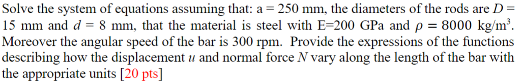

We can use the given info $a=.25$ m, $D_{1}=.015$ m, $D_{2}=.008$ m, $E=2E11$ Pa, $\rho=8000$ kg/m^3, and $\omega=31.42$ rad/s to plug in the matrix and solve for our constants:

$$ A = \pi (\frac{D}{2})^{2} $$

$$ \begin{bmatrix} 0 & 0 & 1 & 0 \\ 0 & 4.9736E-8 & 0 & 1 \\ 1 & -1 & 0 & 0 \\ 7.074E-9 & -2.4868E-8 & 1 & -1 \end{bmatrix} \begin{bmatrix} c_{1} \\ c_{2} \\ c_{3} \\ c_{4} \end{bmatrix} = \begin{bmatrix} 0 \\ 8.227E-7 \\ 31.208 \\ 0 \end{bmatrix} $$

Then using Matlab we can solve for the constants:

$$ c_{1}=50.05 \quad c_{2}=18.845 \quad c_{3}=0 \quad c_{4}=-1.1456E-7 $$

Then we can put these constants back into the equations to define N and u along the length of the bar:

$$ \fbox{$N(x)_{A \rightarrow B} = -A_{1}\rho\omega^{2}\frac{x^{2}}{2} + 50.05$} $$

$$ \fbox{$N(x)_{B\rightarrow C} = -A_{2}\rho\omega^{2}\frac{x^{2}}{2} + 18.845$} $$

both with units of Newtons

$$ \fbox{$u(x)_{A \rightarrow B} = \frac{-\rho\omega^{2}x^{3}}{6E} + \frac{50.05x}{EA_{1}}$} $$

$$ \fbox{$u(x)_{B \rightarrow C} = \frac{-\rho\omega^{2}x^{3}}{6E} + \frac{18.845x}{EA_{2}}-1.1456E-7$} $$

both with units of meters

### Part C

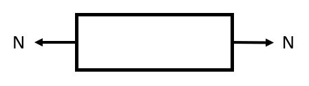

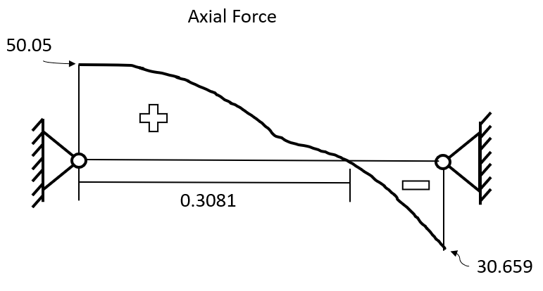

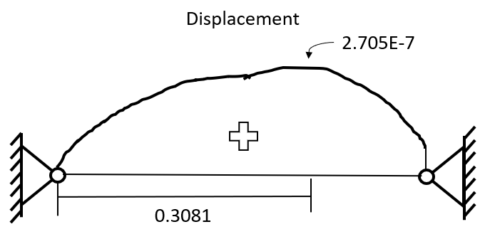

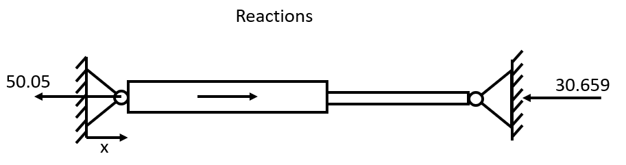

### Part D

The largest tensile and compressive stress can be gotten from the axial force diagram. The maximum tensile stress is at the largest positive axial force and the max compressive is at the largest negative axial force.

However, these values are forces and stress is force per area. To find the stress we will divide by the cross sectional area at those points.

Max tensile = $\frac{50.05}{\pi (.015/2)^{2}} = 283225$ Pa

Max compressive = $\frac{30.659}{\pi (.008/2)^{2}} = 609941$ Pa